# R Notebook

Social Analytics and Strategic Intelligence

Session 1: Explore and Query Let’s bring the data in long format (ByYear_LongStats):

```r
rm(list = ls())
denguelink1='https://github.com/SocialAnalytics-StrategicIntelligence/TableOperations/raw/main/dataFiles/ByYear_LongStats.pkl'

library(reticulate)
use_python("C:/Users/jpnav/anaconda3")
```

```r
#py_install("pandas") # install pandas for R environment
pd <- import("pandas")

dengueLongStats <- pd$read_pickle(denguelink1)

reticulate::py_last_error()
```

```r
str(dengueLongStats)
```

```
'data.frame':   177 obs. of  4 variables:
 $ ano       : num  2000 2000 2000 2001 2001 ...
 $ enfermedad: Ord.factor w/ 3 levels "SIN_SEÑALES"<..: 1 1 1 1 1 1 3 3 3 1 ...
 $ statsName : chr  "edad_mean" "edad_median" "case_sum" "edad_mean" ...
 $ statsValue: num  29.5 27 4324 30.6 28 ...
 - attr(*, "pandas.index")=RangeIndex(start=0, stop=177, step=1)
```

- The average age (mean/median) of infected through the years? by symptoms level?

#Creación de subset para facilitar trabajo

```r
datamean <- subset(dengueLongStats, statsName == "edad_mean")
```

#Gráfico

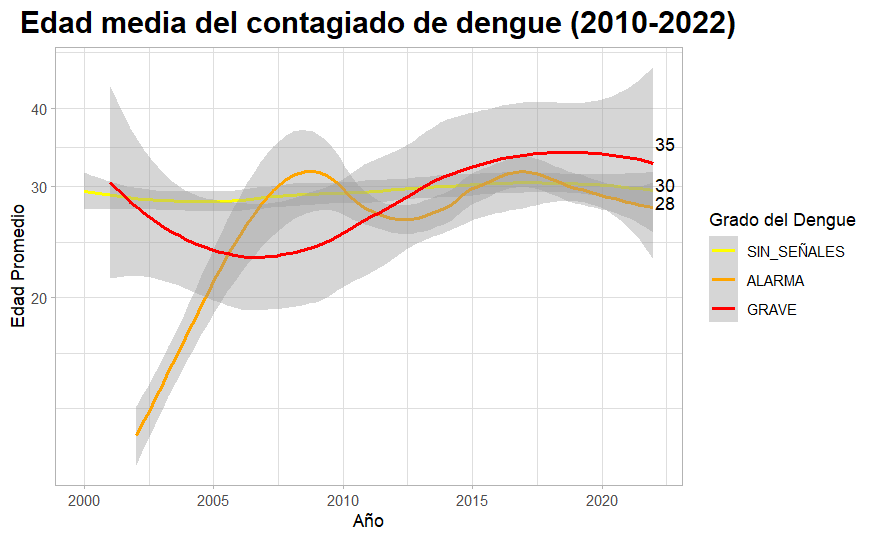

```r
library(ggplot2)
library(dplyr)

last_mean <- datamean %>%
  group_by(enfermedad) %>%
  filter(ano == max(ano))

ggplot(data=datamean, aes(x=ano, y=statsValue, color=enfermedad)) +
  geom_smooth(se=TRUE, method="loess")+
  scale_y_log10(labels=scales::comma) +
  scale_color_manual(values=c("SIN_SEÑALES" = "yellow", "ALARMA" = "orange", "GRAVE" = "red")) +
  theme_light() +
  labs(title="Edad media del contagiado de dengue (2010-2022)",
       x="Año",
       y="Edad Promedio",
       color="Grado del Dengue")+
  theme(plot.title = element_text(hjust = 0.4, face="bold", size=18))+
  geom_text(data=last_mean, aes(label=round(statsValue)), hjust=-0.1, vjust=0.5, color="black", show.legend = FALSE)
```

La edad media del contagiado de dengue vario a través de los años? Fue lo mismo segun gravedad? Respuesta: Como se observa en el gráfico, la edad media del contagiado de dengue sí ha ido variando a través de los años. Las variaciones más notorias se dieron en años anteriores al 2010. Este fenómeno puede deberse a que anterior a dicho año la recopilación de datos referente al dengue era más bien pobre. Posterior al mencionado año, la edad promedio de los contagiados no ha variado de forma notoria, siendo los más afectados, al año 2022, los adultos jóvenes en sus 30 tempranos o 20 tardíos en los 3 grados del dengue: sin señal (sin síntomas), en alarma (con síntomas) y graves.

- The amount of infected through the years? by symptoms level?

#Creación de subset para facilitar trabajo

```r
datacase <- subset(dengueLongStats, statsName == "case_sum")
```

#Gráfico

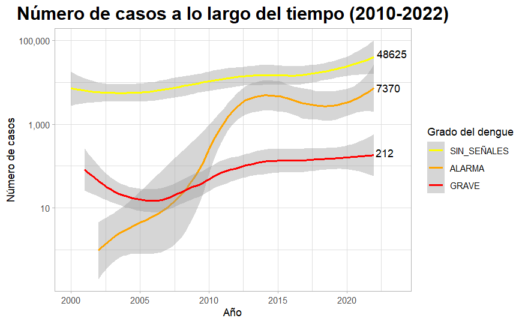

```r
library(ggplot2)
library(dplyr)

last_values <- datacase %>%
  group_by(enfermedad) %>%
  filter(ano == max(ano))

ggplot(data=datacase, aes(x=ano, y=statsValue, color=enfermedad)) +
  geom_smooth(se=TRUE, method="loess")+
  scale_y_log10(labels=scales::comma) +
  scale_color_manual(values=c("SIN_SEÑALES" = "yellow", "ALARMA" = "orange", "GRAVE" = "red")) +
  theme_light() +
  labs(title="Número de casos a lo largo del tiempo (2010-2022)",
       x="Año",
       y="Número de casos",
       color="Grado del dengue")+
  theme(plot.title = element_text(hjust = 0.5, face="bold", size=18))+
  geom_text(data=last_values, aes(label=statsValue), hjust=-0.1, vjust=0.5, color="black", show.legend = FALSE) +
  scale_x_continuous(limits = c(min(datacase$ano), max(datacase$ano) + 1.5))
```

Most affected provinces through the years?

The data worst_ProvYear_alarma_Frequency tell us the frequency of the worst province by region by year:

```r
denguelink2='https://github.com/SocialAnalytics-StrategicIntelligence/TableOperations/raw/main/dataFiles/worst_ProvYear_alarma_Frequency.csv'

dengueProvWorst <- read.csv(denguelink2)


str(dengueProvWorst)
```

```
'data.frame':   43 obs. of  3 variables:
 $ departamento: chr  "AMAZONAS" "AMAZONAS" "ANCASH" "ANCASH" ...
 $ provincia   : chr  "BAGUA" "UTCUBAMBA" "CASMA" "SANTA" ...
 $ case        : int  6 6 5 3 1 7 1 1 10 2 ...
```

For instance, LORETO has data for 14 years:

```r
dengueProvWorst[dengueProvWorst$departamento=='LORETO',]
```

|  | departamento | provincia | case |
| --- | --- | --- | --- |
| 28 | LORETO | ALTO AMAZONAS | 1 |
| 29 | LORETO | MAYNAS | 13 |

In one year, ALTO AMAZONAS was the worst case of people with alarm situation; while MAYNAS had that position for 13 years.

What is the worst cases?

```r
dengueProvWorst[order(-dengueProvWorst$case),]
```

|  | departamento | provincia | case |
| --- | --- | --- | --- |
| 29 | LORETO | MAYNAS | 13 |
| 30 | MADRE DE DIOS | TAMBOPATA | 13 |
| 41 | TUMBES | TUMBES | 12 |
| 43 | UCAYALI | CORONEL PORTILLO | 12 |
| 31 | PASCO | OXAPAMPA | 11 |
| 9 | CAJAMARCA | JAEN | 10 |
| 13 | HUANUCO | LEONCIO PRADO | 10 |
| 33 | PIURA | PIURA | 10 |
| 11 | CUSCO | LA CONVENCION | 9 |
| 19 | JUNIN | CHANCHAMAYO | 9 |

[output cut: 33 more lines]

We could see the distribution of the worst provinces:

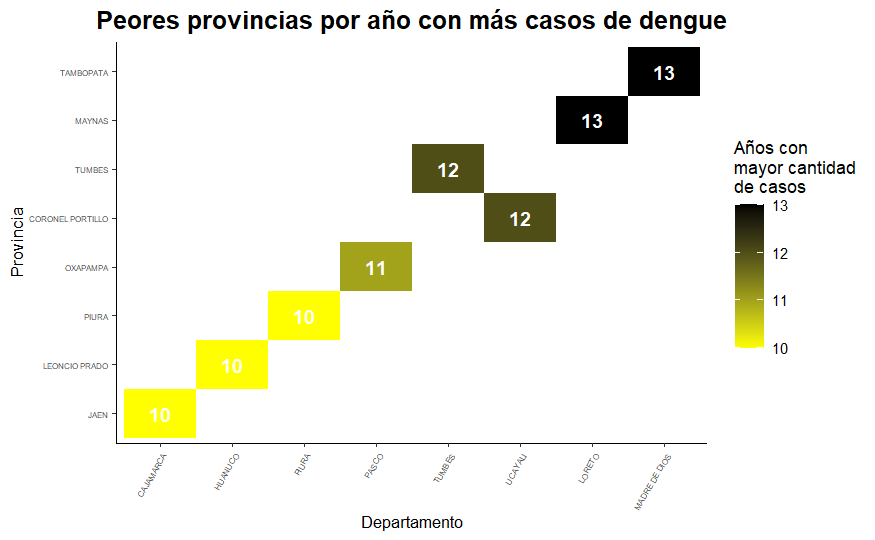

```r
library(dplyr)

dengueProvWorst_peor <- dengueProvWorst %>% filter(case >= 10)

baseHeat  = ggplot(dengueProvWorst_peor, aes(x = reorder(departamento,case), y = reorder(provincia,case), fill=case)) + theme_classic()
heatDefault = baseHeat +  geom_tile()

heatBetter=heatDefault +scale_fill_gradient(low = 'yellow',high = 'black',name="Años con\nmayor cantidad\nde casos")
heatBetter + theme(axis.text.x = element_text(angle = 60,vjust = 1,hjust = 1, size=5),
                   axis.text.y = element_text(size=5),
                   axis.title.x = element_text(size=10),
                   axis.title.y = element_text(size=10)) +
                   geom_text(aes(label=case),
                             size=4,fontface='bold', color='white')+
                   labs(x="Departamento", y="Provincia", title="Peores provincias por año con más casos de dengue")+
                   theme(plot.title = element_text(hjust = 0.5, face="bold", size=15))
```

Cuales fueron las provincias mas afectadas con contagiados a lo largo de los años?

Respuesta: Como se puede ver en el gráfico, las provincias más afectadas a lo largo de los años han sido las provincias de Maynas y Tambopata, siendo en 13 ocasiones las provincias que más casos de dengue registraron en su departamento. Estas son seguidas de Tumbes y Coronel Portillo. En particular, se observa que estas provincias más afectadas son de la región selva, y si no, de climas sumamente cálidos así como lluviosos. Esto es evidente dada la naturaleza del aedes aegypti, quien se ve favorecido de este tipo de climas. Como conclusión, los departamentos de Madre de Dios y Loreto deben realizar un esfuerzo en la prevención y cuidado del dengue en las provincias de Tambopata y Maynas. En general, todos los departamentos presentes en el gráfico deben de prestar atención y cuidado a las provincias observables, dado que ser por 10 años o más la provincia con mayor cantidad de contagios del dengue no es un asunto menor y denota falta de acción por parte de los gobiernos locales.

Let’ see the info about rateAlarma:

```r
denguelink3='https://raw.githubusercontent.com/SocialAnalytics-StrategicIntelligence/TableOperations/main/dataFiles/ByYearPlace.pkl'

dengueYearPlace <- pd$read_pickle(denguelink3)

str(dengueYearPlace)
```

```
'data.frame':   203 obs. of  4 variables:
 $ ano           : num  2012 2012 2012 2012 2012 ...
 $ departamento  : chr  "AMAZONAS" "ANCASH" "CAJAMARCA" "HUANUCO" ...
 $ rateAlarma    : num  0.1263 0.0211 0.1772 0.3092 0.0613 ...
 $ rateAlarma.cut: Ord.factor w/ 6 levels "less10%"<"10-25%"<..: 2 1 2 3 1 1 2 2 2 1 ...
 - attr(*, "pandas.index")=RangeIndex(start=0, stop=203, step=1)
```

Basic stats:

```r
summary(dengueYearPlace)
```

```
      ano       departamento         rateAlarma        rateAlarma.cut
 Min.   :2012   Length:203         Min.   :0.00000   less10%  :97
 1st Qu.:2015   Class :character   1st Qu.:0.03673   10-25%   :46
 Median :2017   Mode  :character   Median :0.10378   25-50    :47
 Mean   :2017                      Mean   :0.19514   51-75%   : 5
 3rd Qu.:2020                      3rd Qu.:0.28067   75-100%  : 5
 Max.   :2022                      Max.   :1.58333   above100%: 3
```

Where and when?

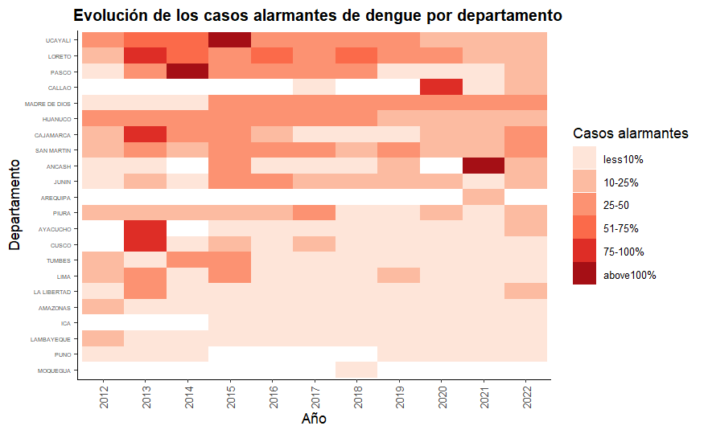

```r
baseHeat  = ggplot(dengueYearPlace, aes(x = as.factor(ano),
                                       y = reorder(departamento, rateAlarma),
                                       fill=rateAlarma.cut)) + theme_classic()
heatDefault = baseHeat +  geom_tile(show.legend = T)

heatBetter=heatDefault +scale_fill_brewer(palette = "Reds")
heatBetter + theme(axis.text.x = element_text(angle = 90, vjust = 0.5, hjust=1, size=8),
                   axis.text.y = element_text(size=4),
                   legend.text = element_text(size=8)) +
                   labs(x = "Año", y = "Departamento", fill = "Casos alarmantes", title = "Evolución de los casos alarmantes de dengue por departamento")+
  theme(plot.title = element_text(hjust = 0.3, face="bold", size=12))
```

Qué relación habia entre los casos alarmantes no graves y los asintomaticos segun departamento a lo largo de los años? Respuesta: Los casos alarmantes no graves a lo largo de los años han ido bajando su porcentaje en proporción al número de casos asintomáticos.